# Practical Machine Learning Course Project

jeefmarko

July 23, 2021

## Summary

This project is about predicting some classes (`classe`) from a dataset with measurement from weareble devices. Access to the codebook was not available. After preprocessing the data and selecting the best features via PCA, we build a predictive model based on the random forest algorithm.

## Data Understanding

Let us read the data and see how big it is.

```r
training = read.table('https://d396qusza40orc.cloudfront.net/predmachlearn/pml-training.csv',
                      sep = ',',header = T,na.strings = c("","NA",'#DIV/0'))
dim(training)
```

```
## [1] 19622   160
```

We see there are 19622 rows and 160 columns. We would like a parsimonious model. To this end we will look into the variables to detect which contain little or no information.

### Missing values

We first remove all columns with mostly `NA`.

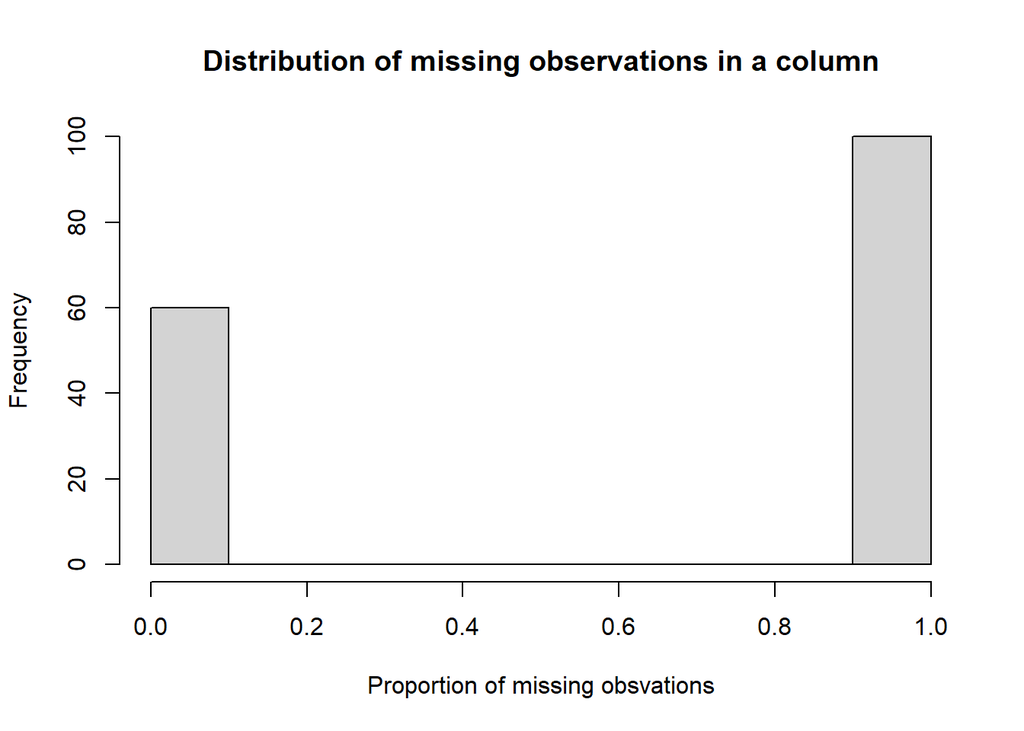

```r
# The  missing function computes the percernetage of NA in col
missing = function(col){
  sum(is.na(col))/length(col)
}

# View distribution of missing values in cols of training
sapply(training,missing) %>% hist(xlab= 'Proportion of missing obsvations',
                                  main='Distribution of missing observations in a column') # Good threshold of .8
```

We see that the distribution of missing values in the columns of `training` is concentrated into two subgroups. A proportion of `0.8` will serve as an adequate cutoff.

```r
badcols = unname(sapply(training,missing)>.8)
goodTraining = training[,!badcols]
goodTraining[1:10,1:10]
```

```
##     X user_name raw_timestamp_part_1 raw_timestamp_part_2   cvtd_timestamp
## 1   1  carlitos           1323084231               788290 05/12/2011 11:23
## 2   2  carlitos           1323084231               808298 05/12/2011 11:23
## 3   3  carlitos           1323084231               820366 05/12/2011 11:23
## 4   4  carlitos           1323084232               120339 05/12/2011 11:23
## 5   5  carlitos           1323084232               196328 05/12/2011 11:23
## 6   6  carlitos           1323084232               304277 05/12/2011 11:23
## 7   7  carlitos           1323084232               368296 05/12/2011 11:23
## 8   8  carlitos           1323084232               440390 05/12/2011 11:23
## 9   9  carlitos           1323084232               484323 05/12/2011 11:23
## 10 10  carlitos           1323084232               484434 05/12/2011 11:23
##    new_window num_window roll_belt pitch_belt yaw_belt
## 1          no         11      1.41       8.07    -94.4
## 2          no         11      1.41       8.07    -94.4
## 3          no         11      1.42       8.07    -94.4
## 4          no         12      1.48       8.05    -94.4
## 5          no         12      1.48       8.07    -94.4
## 6          no         12      1.45       8.06    -94.4
## 7          no         12      1.42       8.09    -94.4
## 8          no         12      1.42       8.13    -94.4
## 9          no         12      1.43       8.16    -94.4
## 10         no         12      1.45       8.17    -94.4
```

Having eliminated the columns with missing values, we eliminate other columns in `goodTraining` that will not be used for the predictive model. These include `X` (id name), the date/time variables `raw_timestamp_part_1`, `raw_timestamp_part_2`, and `new_window` which is dominated by `no`.

```r
# rownames to remove
remCols = c(1,3,4,5)

## new_window seems to be dominated by 'no'
yn = goodTraining$new_window %>% table()
print(paste('Proportion of `no` in `new_window`: ',
            1-(prod(yn/sum(yn)) / sum(yn)) %>% sqrt))
```

```
## [1] "Proportion of `no` in `new_window`:  0.99898379903087"
```

```r
# indeed the SE is about 0.001. This is col 6 in goodTraining

# Remove all from goodTraining
remCols = c(remCols,6)
goodTraining1 = goodTraining[,-remCols]
```

## Columns with little to no variability

There may other constant or almost constant columns. The following chunch investigates this possibility.

```r
## Little variability

# near zero?  same as small variance
nzv = nearZeroVar(goodTraining1,saveMetrics = T)
dfDesc = describe(goodTraining1)
rem = data.frame(nzv,small_var = dfDesc[,4] <.5) %>%
  filter(nzv==T) %>% nrow
print(rem) # no cols with nzv
```

```
## [1] 0
```

## Correlated variables

Next we investigate whether the remaining variables of numerical type (int or numerical) in `goodTraining` are correlated.

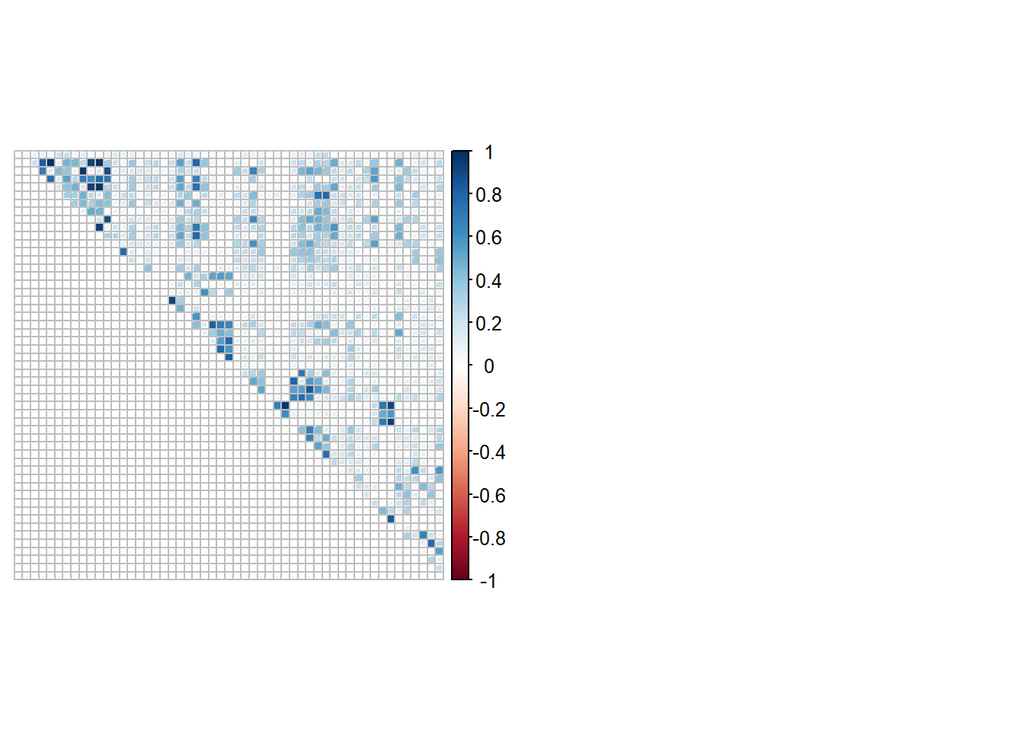

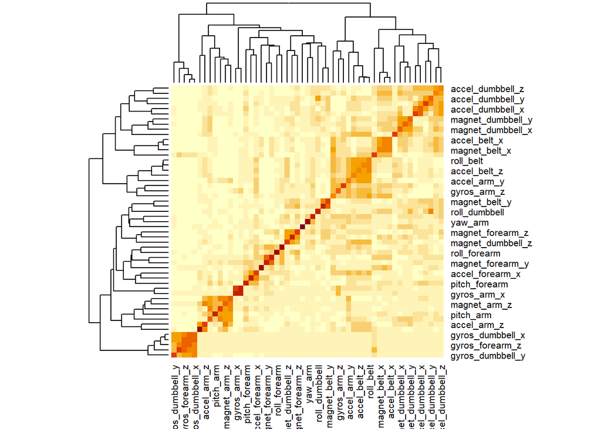

```r
# Grab numerical variables
numvarIdx = goodTraining1 %>%
            as_tibble() %>%
            sapply(.,class) %>%
            unname %>%
            grep('^[in]',.)

# Get correlation matrix for numerical variables
CorMat <-  cor(goodTraining1[,numvarIdx]) %>% abs
CorMat1 = CorMat
CorMat1[lower.tri(CorMat1,diag = T)] = 0 # consider upper triaag part due to symmetry
par(mfrow = c(1,2))
corrplot(CorMat1, method="square",diag =F,tl.pos = 'n' )
heatmap(CorMat)
```

Some of the variables seem to be correlated. To futher reduce dimensionality, PCA will be included in the modeling that follows.

# Modeling

As mentioned, we will produce a random forest model for the prectiction of the `classe` on the `testing` data. In the following chunk, we fit a `rf` model with PCA preprocessing with 5-fold crossvalidation.

```r
classeIdx = which('classe' == colnames(goodTraining1))
stopifnot(classeIdx==55)
x=goodTraining1[,-classeIdx]
y=goodTraining1[,classeIdx]

cluster <- makeCluster(detectCores() - 1) # convention to leave 1 core for OS
registerDoParallel(cluster)

fitControl <- trainControl(method = "cv",
                           number = 5,
                           allowParallel = TRUE)

# system.time(fit <- train(x=x,y=y , method="rf", data=goodTraining2,
system.time(fit <- train(x=x,y=y,method="rf",preProcess="pca",
data=goodTraining1, trControl = fitControl))
```

```
##    user  system elapsed
##   31.86    8.22  296.52
```

```r
stopCluster(cluster)
registerDoSEQ()
```